# Engranajes

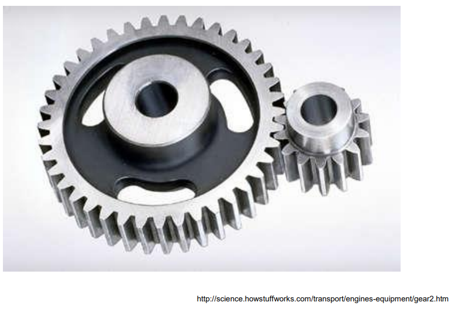

```python
%%html

<iframe width="560" height="315" src="https://www.youtube.com/embed/JOLtS4VUcvQ" title="YouTube video player" frameborder="0" allow="accelerometer; autoplay; clipboard-write; encrypted-media; gyroscope; picture-in-picture" allowfullscreen></iframe>
```

[video not shown]

- Elementos de máquina
- Transmiten energía (movimiento)
- Naturaleza Rotacional
- Hay de muchos tipos y formas
  - Engranajes cilíndricos rectos / helicoidales
  - Engranajes cónicos
  - Piñón - cremallera
  - Sinfín - corona
  - ...otros
- **Permiten cambiar relaciones de velocidad**

## Ley fundamental de los engranajes

*Para mantener una razón de velocidad constante, la localización del punto de paso P debe ser constante.*

Para que esto se cumpla, el punto de contacto entre los dientes debe desplazarse en forma rectilínea:

[figure not shown]

*Fuente: https://youtu.be/8s4zm_ajxAA*

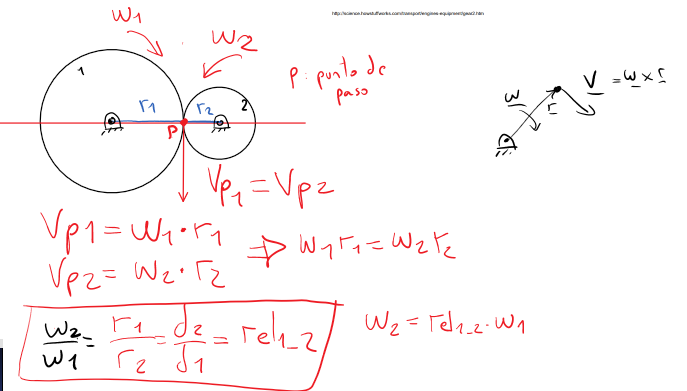

si definimos $\omega_2$ como la velocidad angular del engranaje de salida $\omega_{out}$ y ($\omega_1$) como la velocidad angular del engranaje de entrada ($\omega_{in}$), y dado que los diámetros de dichos engranajes se expresan como $d_{out} = 2r_{out}$ y $d_{in} = 2r_{in}$, entonces

\begin{equation} \frac{\omega_{out}}{\omega_{in}}=\frac{d_{in}}{d_{out}}=rel_{out\_in} \end{equation}

por lo cual,

\begin{equation} \omega_{out}= \omega_{in} rel_{out\_in} \end{equation}

Sin embargo, los diámetros de paso suelen ser difíciles de medir. Podemos aprovecharnos de las características de los engranajes para calcular la relación de velocidad.

Primero, debemos preguntarnos, para que dos engranajes puedan **engranar**, ¿qué se debe cumplir?

- **ambos deben tener los dientes con una distribución uniforme**
- **los dientes deben ser del MISMO TAMAÑO**

veamos esto con números

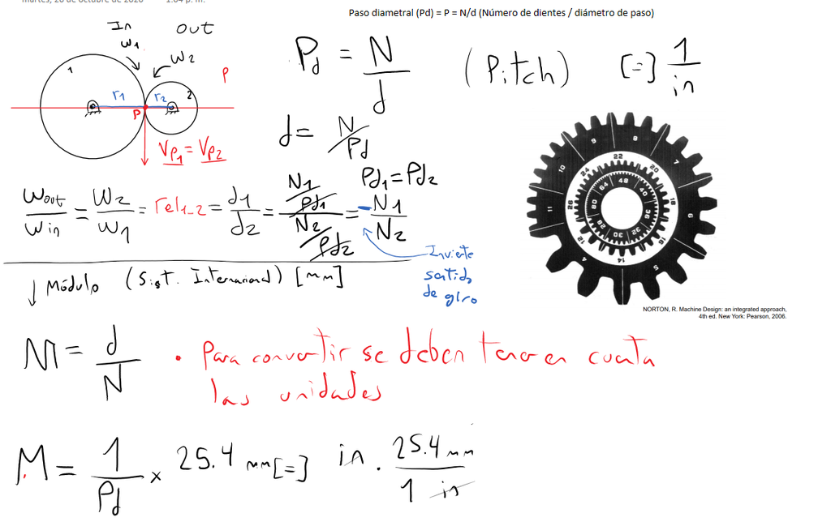

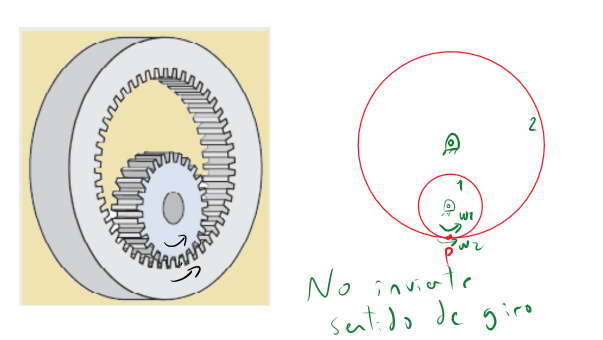